# problema3-ck4

## QUESTÃO 4

4. Nos anos que houve decréscimo na produção de filmes, quais as estimativas ou Qual o gênero mais assistido?

Se observarmos curidadosamente as quantidades de lançamentos em cada ano, vamos perceber que em alguns anos houve decréscimo de lançamento. Acredito ser possível traçar um relacionamente entre alguns fatores de econômia, por exemplo. Mas no meu caso irei apenas demostrar quais os filmes que as pessoas preferiram nestes anos.

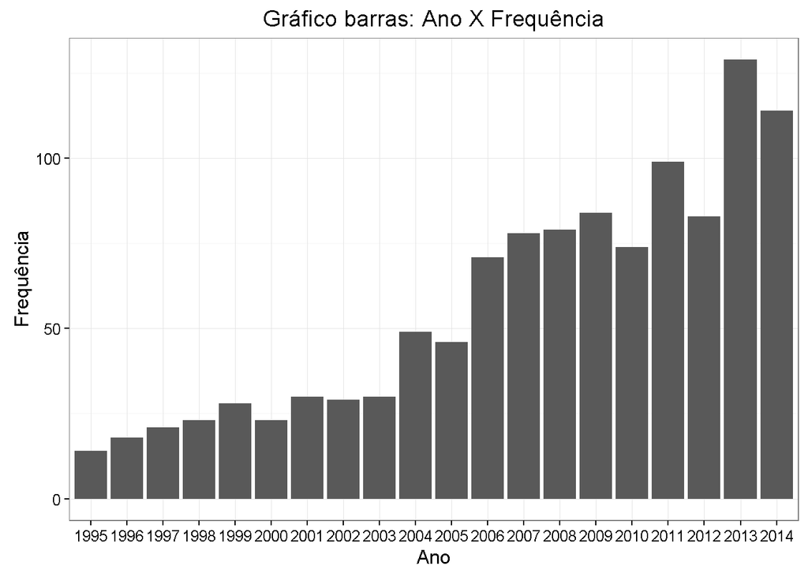

```r
#tabela com valores eplotagem

x<-table(filmes_tratados$AnoLancamento)

x<-as.data.frame(x)

ggplot(data = x,aes(x= x$Var1, y= x$Freq) )+geom_bar(stat = "identity")+ylab("Frequência")+xlab("Ano")+ggtitle("Gráfico barras: Ano X Frequência" )
```

```r
#organizando dados

ft4<-filmes_tratados[, c(2,3,8,10,11)]#Titulo, Genero e Publico
#View(ft4)

#limpando e tratando os valores

ft4$Publico<-as.character(ft4$Publico)


#remove pontos de Publico
ponto<-'\\.'

for(i in 1:length(ft4$Publico)){
  ft4[i,5]<-gsub(ponto,"",ft4[i,5])}

ft4$Publico<-as.numeric(ft4$Publico)

#remove pontos e virgulas de --renda
ft4$Renda<-as.character(ft4$Renda)
ponto<-'\\.'

for(i in 1:length(ft4$Renda)){
  ft4[i,4]<-gsub(ponto,"",ft4[i,4])}

virg<-'\\,'

for(i in 1:length(ft4$Renda)){
  ft4[i,4]<-gsub(virg,".",ft4[i,4])}

#transforma numérico
ft4$Renda<-as.numeric(ft4$Renda)

#Pega apenas quem rendeu mais de mil reaise teve mais de mil espectadores

ft4<-ft4[, c(1,3,4,5)]
ft4<-filter(ft4,Renda>1000, Publico>1000)


media_ft4<-group_by(ft4,AnoLancamento)%>%summarise(mediaR=mean(Renda),mediaP=mean(Publico))
View(media_ft4)

 knitr::kable(media_ft4, caption = "Médias de Renda e Publico")
```

Médias de Renda e Publico

| AnoLancamento | mediaR | mediaP |
| --- | --- | --- |
| 1995 | 1048649.1 | 234179.14 |
| 1996 | 278656.1 | 62946.18 |
| 1997 | 788782.7 | 178614.90 |
| 1998 | 809421.9 | 188285.09 |
| 1999 | 1009949.4 | 243605.20 |
| 2000 | 1436821.4 | 288239.50 |
| 2001 | 1349197.0 | 264935.50 |
| 2002 | 1404177.9 | 256053.96 |
| 2003 | 4666351.1 | 768648.48 |
| 2004 | 2223506.1 | 336576.04 |
| 2005 | 1663813.3 | 236700.63 |
| 2006 | 1291148.7 | 176162.11 |
| 2007 | 1120537.8 | 143652.59 |
| 2008 | 1048302.8 | 136681.22 |
| 2009 | 2274010.5 | 278679.16 |
| 2010 | 3757844.3 | 421650.47 |
| 2011 | 2409900.4 | 261858.64 |
| 2012 | 3456776.4 | 340229.52 |
| 2013 | 3311759.2 | 306618.82 |
| 2014 | 2207233.2 | 188173.61 |

Irei trabalhar apenas com os anos em que houve diminuição da quantidade de filmes em relação ao seu ano anterior, neste caso são 06: 2000, 2002, 2005, 2010,2012, 2014.

```r
  ft4<-filter(ft4, AnoLancamento=='2000'| AnoLancamento=='2002'|AnoLancamento=='2005'|AnoLancamento=='2010'|AnoLancamento=='2012'|AnoLancamento=='2014' )

#Médias de Renda e Publico dos anos de decréscimo
medias_ft4<-group_by(ft4,AnoLancamento)%>%summarise(mediaR=mean(Renda),mediaP=mean(Publico))

knitr::kable(medias_ft4, caption = "Médias de Renda e Publico dos anos de decréscimo")
```

Médias de Renda e Publico dos anos de decréscimo

| AnoLancamento | mediaR | mediaP |
| --- | --- | --- |
| 2000 | 1436821 | 288239.5 |
| 2002 | 1404178 | 256054.0 |
| 2005 | 1663813 | 236700.6 |
| 2010 | 3757844 | 421650.5 |
| 2012 | 3456776 | 340229.5 |
| 2014 | 2207233 | 188173.6 |

```r
#Aqui é possível perceber que dentro desses anos os filmes de ficção ciêntífica tiveram tanto renda quando Público bem maior que os demais.

medias_ft4<-group_by(ft4, Genero)%>%summarise(mediaR=mean(Renda),mediaP=mean(Publico))
#View(medias_ft4)
knitr::kable(medias_ft4, caption = "Médias de Renda e Publico dos anos dos gêneros")
```

Médias de Renda e Publico dos anos dos gêneros

| Genero | mediaR | mediaP |
| --- | --- | --- |
| Animação | 858428.7 | 114146.83 |
| Documentário | 170079.6 | 19930.38 |
| Ficção | 3574002.9 | 399576.81 |

```r
#Como foram poucos filmes de Animação (apenas 06), irei retirálos do experimento, e agir em cima apenas de documentário e Ficção.

ft4<-filter(ft4,Genero!="Animação")
```

Agora veremos as estimativas de público e rendas em anos de decrescimo apenas para os gêneros Documentário e Ficção:

```r
medias_ft4<-group_by(ft4,AnoLancamento)%>%summarise(mediaR=mean(Renda),mediaP=mean(Publico))

knitr::kable(medias_ft4, caption = "Médias de Renda e Publico dos anos de decréscimo")
```

Médias de Renda e Publico dos anos de decréscimo

| AnoLancamento | mediaR | mediaP |
| --- | --- | --- |
| 2000 | 1436821 | 288239.5 |
| 2002 | 1404178 | 256054.0 |
| 2005 | 1602021 | 228140.7 |
| 2010 | 3757844 | 421650.5 |
| 2012 | 3576557 | 351953.4 |
| 2014 | 2279624 | 194268.5 |

```r
#Aqui é possível perceber que dentro desses anos os filmes de ficção ciêntífica tiveram tanto renda quando Público bem maior que os demais.

medias_ft4<-group_by(ft4, Genero)%>%summarise(mediaR=mean(Renda),mediaP=mean(Publico))
#View(medias_ft4)

medias_ft4<-group_by(ft4, Genero)%>%summarise(mediaR=mean(Renda),mediaP=mean(Publico))
knitr::kable(medias_ft4, caption = "Médias de Renda e Publico dos anos dos gêneros")
```

Médias de Renda e Publico dos anos dos gêneros

| Genero | mediaR | mediaP |
| --- | --- | --- |
| Documentário | 170079.6 | 19930.38 |
| Ficção | 3574002.9 | 399576.81 |

```r
#Ficção - Documentário Média Público
dif_mediap_21 = medias_ft4[2,3] - medias_ft4[1,3]
print(paste("Diferença na mediana observada:", round(dif_mediap_21),".Seria Melhor Ficção"))
```

[1] “Diferença na mediana observada: 379646 .Seria Melhor Ficção”

```r
#Ficção - Documentário Média Renda
dif_mediar_21=medias_ft4[2,2]-medias_ft4[1,2]
print(paste("Diferença na media observada:", round(dif_mediar_21), ".Seria Melhor Ficção"))
```

[1] “Diferença na media observada: 3403923 .Seria Melhor Ficção”

**Iniciando as probabilidades**